# CTT Fərziyyələri və Yoxlanılması

Klassik Test Nəzəriyyəsinin Fundamental Fərziyyələrinin Tədqiqi

Klassik Test Nəzəriyyəsi Kursu

2025-07-17

## 0.1 Dərsin Məqsədləri

✓ CTT-nin üç fundamental fərziyyəsini dərindən anlamaq  
✓ Fərziyyələrin statistik yoxlanma metodlarını öyrənmək  
✓ Fərziyyə pozuntuları və onların nəticələrini tədqiq etmək  
✓ Real məlumatlarla fərziyyə testlərini aparmaq

## 0.2 Əvvəlki Dərslərə Baxış

**Dərs 1-2-də öyrəndiklərimiz:** - **X = T + E** modelinin əsasları - Həqiqi bal və xəta komponentlərinin mahiyyəti - Etibarlılıq anlayışının CTT konteksti - R simulyasiyaları ilə model nümayişi

**İndi daha dərinə gedəcəyik:** Modelin işləməsi üçün vacib olan fərziyyələri araşdıracağıq.

# 1 CTT-nin Üç Fundamental Fərziyyəsi

Allen və Yen (2002, səh. 35-42) kitabında **Klassik Test Nəzəriyyəsinin** üç əsas fərziyyəsi müfəssəl izah edilir:

## 1.1 Fərziyyələrin Ümumi Baxışı

```r
# Fərziyyələrin xarakteristikaları
assumptions_data <- data.frame(
  Ferziyye = c("E(e) = 0", "Cor(T,e) = 0", "Cor(e₁,e₂) = 0"),
  Adı = c("Tərəfsiz Xəta", "Müstəqil Xəta", "Xəta Müstəqilliyi"),
  Mana = c("Xətanın gözlənilən dəyəri sıfırdır",
           "Həqiqi bal və xəta müstəqildir",
           "Müxtəlif testlərdə xətalar müstəqildir"),
  Ehemiyyet = c(10, 9, 8),
  Yoxlanma_Usulu = c("t-test, Shapiro-Wilk", "Korrelyasiya testi", "Korrelyasiya matrisi")
)

kable(assumptions_data, caption = "CTT-nin Üç Fundamental Fərziyyəsi")
```

CTT-nin Üç Fundamental Fərziyyəsi

| Ferziyye | Adı | Mana | Ehemiyyet | Yoxlanma_Usulu |
| --- | --- | --- | --- | --- |
| E(e) = 0 | Tərəfsiz Xəta | Xətanın gözlənilən dəyəri sıfırdır | 10 | t-test, Shapiro-Wilk |
| Cor(T,e) = 0 | Müstəqil Xəta | Həqiqi bal və xəta müstəqildir | 9 | Korrelyasiya testi |
| Cor(e₁,e₂) = 0 | Xəta Müstəqilliyi | Müxtəlif testlərdə xətalar müstəqildir | 8 | Korrelyasiya matrisi |

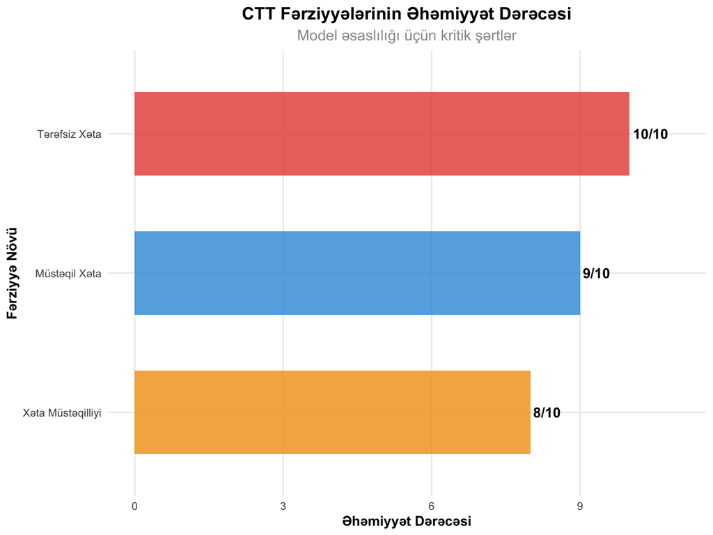

```r
# Fərziyyələrin əhəmiyyət dərəcəsi
ggplot(assumptions_data, aes(x = reorder(Adı, Ehemiyyet), y = Ehemiyyet, fill = Adı)) +
  geom_col(alpha = 0.8, width = 0.6) +
  geom_text(aes(label = paste0(Ehemiyyet, "/10")),
            hjust = -0.1, fontface = "bold", size = 4) +
  coord_flip() +
  scale_fill_manual(values = colors_basic[1:3]) +
  labs(title = "CTT Fərziyyələrinin Əhəmiyyət Dərəcəsi",
       subtitle = "Model əsaslılığı üçün kritik şərtlər",
       x = "Fərziyyə Növü", y = "Əhəmiyyət Dərəcəsi") +
  theme_clean() +
  theme(legend.position = "none") +
  ylim(0, 11)
```

# 2 Fərziyyə 1: E(e) = 0 (Tərəfsiz Xəta)

## 2.1 Fərziyyənin Mənası

**Allen və Yen (2002, səh. 36)** bu fərziyyəni belə izah edir:

> **E(e) = 0** fərziyyəsi o deməkdir ki, xəta komponentinin gözlənilən dəyəri (ortası) sıfırdır. Bu, xətaların sistematik tərəfi olmadığını göstərir.

### 2.1.1 Niyə Vacibdir?

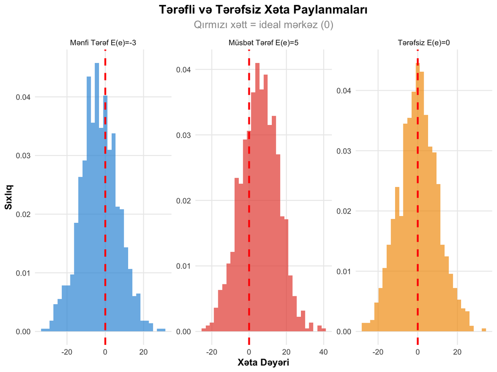

```r
# Tərəfli və tərəfsiz xəta müqayisəsi
set.seed(123)
n <- 1000

# Tərəfsiz xəta (ideal hal)
unbiased_error <- rnorm(n, mean = 0, sd = 10)

# Tərəfli xəta (problemli hal)
biased_error_positive <- rnorm(n, mean = 5, sd = 10)
biased_error_negative <- rnorm(n, mean = -3, sd = 10)

error_comparison <- data.frame(
  Error = c(unbiased_error, biased_error_positive, biased_error_negative),
  Type = rep(c("Tərəfsiz E(e)=0", "Müsbət Tərəf E(e)=5", "Mənfi Tərəf E(e)=-3"), each = n)
)

# Vizuallaşdırma
ggplot(error_comparison, aes(x = Error, fill = Type)) +
  geom_histogram(aes(y = after_stat(density)), bins = 30, alpha = 0.7) +
  geom_vline(xintercept = 0, linetype = "dashed", color = "red", size = 1) +
  facet_wrap(~Type, scales = "free") +
  scale_fill_manual(values = colors_basic[1:3]) +
  labs(title = "Tərəfli və Tərəfsiz Xəta Paylanmaları",
       subtitle = "Qırmızı xətt = ideal mərkəz (0)",
       x = "Xəta Dəyəri", y = "Sıxlıq") +
  theme_clean() +
  theme(legend.position = "none")
```

```r
# Statistik test nəticələri
error_stats <- error_comparison %>%
  group_by(Type) %>%
  summarise(
    Orta = round(mean(Error), 3),
    Standart_Sapma = round(sd(Error), 3),
    t_test_p = round(t.test(Error, mu = 0)$p.value, 4),
    .groups = 'drop'
  )

kable(error_stats, caption = "Xəta Növlərinin Statistik Xarakteristikaları")
```

Xəta Növlərinin Statistik Xarakteristikaları

| Type | Orta | Standart_Sapma | t_test_p |
| --- | --- | --- | --- |
| Müsbət Tərəf E(e)=5 | 5.425 | 10.097 | 0.0000 |
| Mənfi Tərəf E(e)=-3 | -3.201 | 9.784 | 0.0000 |
| Tərəfsiz E(e)=0 | 0.161 | 9.917 | 0.6072 |

## 2.2 Fərziyyənin Yoxlanma Metodları

```r
# E(e) = 0 fərziyyəsinin statistik yoxlanması

# Simulyasiya məlumatları
set.seed(456)
n_subjects <- 100
true_scores <- rnorm(n_subjects, mean = 75, sd = 15)

# 3 fərqli ssenari
scenarios <- list(
  "İdeal Hal" = list(mean = 0, sd = 8),
  "Çox Az Tərəf" = list(mean = 1, sd = 8),
  "Aydın Tərəf" = list(mean = 4, sd = 8)
)

test_results <- data.frame()

for(scenario_name in names(scenarios)) {
  scenario <- scenarios[[scenario_name]]

  # Xəta yaradılması
  errors <- rnorm(n_subjects, mean = scenario$mean, sd = scenario$sd)
  observed <- true_scores + errors

  # Testlər
  t_test_result <- t.test(errors, mu = 0)
  shapiro_test <- shapiro.test(errors)

  # Nəticələri toplayırıq
  temp_result <- data.frame(
    Ssenari = scenario_name,
    Xeta_Ortasi = round(mean(errors), 3),
    t_test_p = round(t_test_result$p.value, 4),
    Shapiro_p = round(shapiro_test$p.value, 4),
    Nezere_Ferzi = ifelse(t_test_result$p.value > 0.05, "Qəbul", "Rədd"),
    Normal_Paylanma = ifelse(shapiro_test$p.value > 0.05, "Normal", "Qeyri-normal")
  )

  test_results <- rbind(test_results, temp_result)
}

kable(test_results, caption = "E(e) = 0 Fərziyyəsinin Statistik Testləri")
```

E(e) = 0 Fərziyyəsinin Statistik Testləri

| Ssenari | Xeta_Ortasi | t_test_p | Shapiro_p | Nezere_Ferzi | Normal_Paylanma |
| --- | --- | --- | --- | --- | --- |
| İdeal Hal | -0.934 | 0.2325 | 0.0200 | Qəbul | Qeyri-normal |
| Çox Az Tərəf | 1.789 | 0.0213 | 0.9906 | Rədd | Normal |
| Aydın Tərəf | 5.083 | 0.0000 | 0.4627 | Rədd | Normal |

## 2.3 Fərziyyə Pozuntusu Halları

```r
# E(e) = 0 fərziyyəsinin pozulmasının nəticələri

set.seed(789)
n_students <- 200

# Müxtəlif tərəf səviyyələri
bias_levels <- c(0, 2, 5, 8)
violation_effects <- data.frame()

for(bias in bias_levels) {
  true_abilities <- rnorm(n_students, 50, 10)
  errors <- rnorm(n_students, bias, 6)  # Tərəfli xəta
  observed <- true_abilities + errors

  # Etibarlılıq və digər metrikalar
  reliability <- var(true_abilities) / var(observed)
  correlation <- cor(true_abilities, observed)
  mean_error <- mean(errors)

  temp_data <- data.frame(
    Teref_Seviyyesi = bias,
    Orta_Xeta = round(mean_error, 2),
    Etibarlilik = round(reliability, 3),
    Korrelyasiya = round(correlation, 3),
    Sistematik_Xeta = ifelse(abs(mean_error) > 1, "Var", "Yox")
  )

  violation_effects <- rbind(violation_effects, temp_data)
}

kable(violation_effects, caption = "E(e) = 0 Pozuntusunun Təsirlər")
```

E(e) = 0 Pozuntusunun Təsirlər

| Teref_Seviyyesi | Orta_Xeta | Etibarlilik | Korrelyasiya | Sistematik_Xeta |
| --- | --- | --- | --- | --- |
| 0 | 0.10 | 0.720 | 0.858 | Yox |
| 2 | 1.72 | 0.702 | 0.835 | Var |
| 5 | 4.97 | 0.836 | 0.867 | Var |
| 8 | 8.22 | 0.800 | 0.867 | Var |

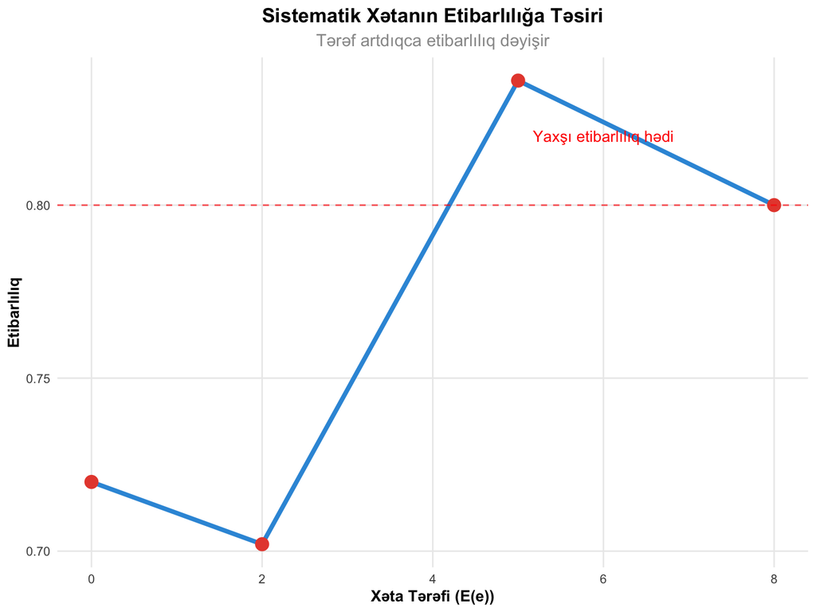

```r
# Vizual təqdimat
ggplot(violation_effects, aes(x = Teref_Seviyyesi, y = Etibarlilik)) +
  geom_line(size = 1.5, color = colors_basic[1]) +
  geom_point(size = 4, color = colors_basic[2]) +
  geom_hline(yintercept = 0.8, linetype = "dashed", color = "red", alpha = 0.7) +
  annotate("text", x = 6, y = 0.82, label = "Yaxşı etibarlılıq hədi", color = "red") +
  labs(title = "Sistematik Xətanın Etibarlılığa Təsiri",
       subtitle = "Tərəf artdıqca etibarlılıq dəyişir",
       x = "Xəta Tərəfi (E(e))", y = "Etibarlılıq") +
  theme_clean()
```

# 3 Fərziyyə 2: Cor(T,e) = 0 (Müstəqil Xəta)

## 3.1 Fərziyyənin Mənası

**Allen və Yen (2002, səh. 38-39)** ikinci fərziyyəni belə izah edir:

> **Cor(T,e) = 0** fərziyyəsi həqiqi bal və xəta komponentinin bir-birindən müstəqil olduğunu bildirir. Yəni, qabiliyyəti yüksək olan insanların xətası da yüksək olmamalıdır.

## 3.2 Fərziyyənin Tədqiqi

```r
# Cor(T,e) = 0 fərziyyəsinin simulyasiyası

set.seed(321)
n_obs <- 500

# 3 ssenari: müstəqil, zəif asılı, güclü asılı
true_scores <- rnorm(n_obs, 60, 12)

# Ssenari 1: Müstəqil xəta (ideal)
independent_error <- rnorm(n_obs, 0, 8)

# Ssenari 2: Zəif asılı xəta
weak_dependent_error <- 0.2 * true_scores + rnorm(n_obs, 0, 7)

# Ssenari 3: Güclü asılı xəta
strong_dependent_error <- 0.5 * true_scores + rnorm(n_obs, 0, 5)

# Məlumat strukturu
dependency_data <- data.frame(
  True_Score = rep(true_scores, 3),
  Error = c(independent_error, weak_dependent_error, strong_dependent_error),
  Scenario = rep(c("Müstəqil (r=0)", "Zəif Asılı (r≈0.2)", "Güclü Asılı (r≈0.5)"), each = n_obs)
)

# Korrelyasiya hesablamaları
correlation_results <- dependency_data %>%
  group_by(Scenario) %>%
  summarise(
    Korrelyasiya = round(cor(True_Score, Error), 3),
    Korrelyasiya_Test_p = round(cor.test(True_Score, Error)$p.value, 4),
    Ferzi_Veziyyeti = ifelse(abs(cor(True_Score, Error)) < 0.1, "Qəbul", "Rədd"),
    .groups = 'drop'
  )

kable(correlation_results, caption = "Cor(T,e) = 0 Fərziyyəsinin Yoxlanması")
```

Cor(T,e) = 0 Fərziyyəsinin Yoxlanması

| Scenario | Korrelyasiya | Korrelyasiya_Test_p | Ferzi_Veziyyeti |
| --- | --- | --- | --- |
| Güclü Asılı (r≈0.5) | 0.746 | 0.0000 | Rədd |
| Müstəqil (r=0) | -0.015 | 0.7347 | Qəbul |
| Zəif Asılı (r≈0.2) | 0.332 | 0.0000 | Rədd |

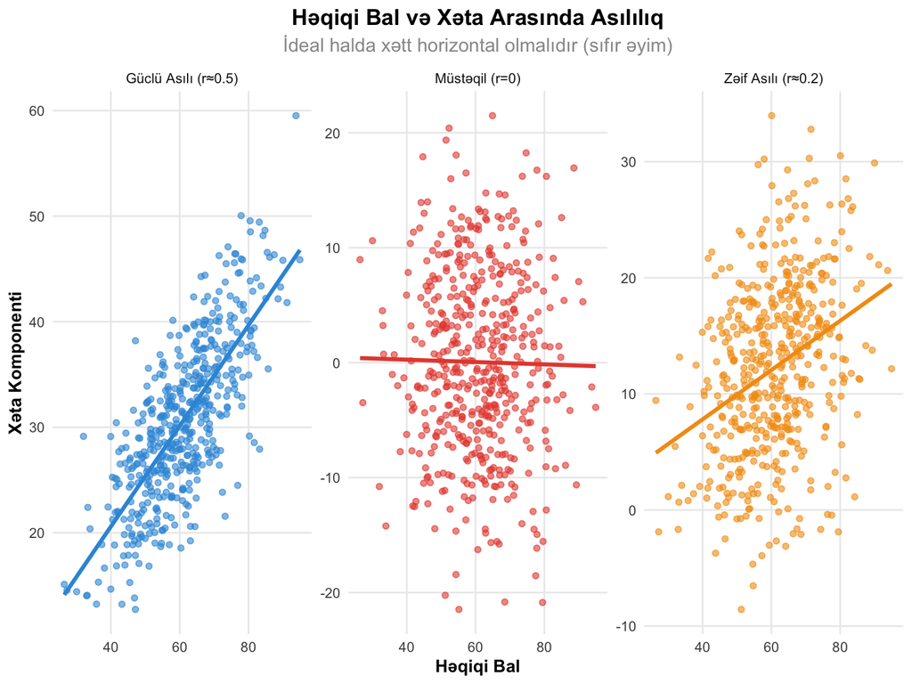

```r
# Vizual təqdimat
ggplot(dependency_data, aes(x = True_Score, y = Error, color = Scenario)) +
  geom_point(alpha = 0.6) +
  geom_smooth(method = "lm", se = FALSE, size = 1.2) +
  facet_wrap(~Scenario, scales = "free") +
  scale_color_manual(values = colors_basic[1:3]) +
  labs(title = "Həqiqi Bal və Xəta Arasında Asılılıq",
       subtitle = "İdeal halda xətt horizontal olmalıdır (sıfır əyim)",
       x = "Həqiqi Bal", y = "Xəta Komponenti") +
  theme_clean() +
  theme(legend.position = "none")
```

## 3.3 Praktik Nümunələr

```r
# Cor(T,e) = 0 pozuntusunun real nümunələri

# Nümunə 1: Test kaygısı effekti
set.seed(654)
n <- 300
ability <- rnorm(n, 100, 15)

# Yüksək qabiliyyətli tələbələr daha çox kaygılanır
anxiety_effect <- ifelse(ability > 110, rnorm(sum(ability > 110), -5, 3),
                        rnorm(sum(ability <= 110), 0, 4))

# Nümunə 2: Motivasiya effekti
# Aşağı qabiliyyətli tələbələr daha az səy göstərir
motivation_effect <- ifelse(ability < 90, rnorm(sum(ability < 90), -3, 2),
                           rnorm(sum(ability >= 90), 1, 3))

# Nümunə 3: Səhv cavab nümunəsi effekti
# Orta qabiliyyətli tələbələr daha çox nümunə səhv edir
guessing_effect <- ifelse(ability > 85 & ability < 115,
                         rnorm(sum(ability > 85 & ability < 115), 2, 2),
                         rnorm(sum(ability <= 85 | ability >= 115), 0, 2))

practical_examples <- data.frame(
  Ability = rep(ability, 3),
  Error = c(anxiety_effect, motivation_effect, guessing_effect),
  Effect_Type = rep(c("Test Kaygısı", "Motivasiya Çatışmazlığı", "Səhv Cavab Nümunəsi"), each = n)
)

# Korrelyasiya analizi
practical_correlations <- practical_examples %>%
  group_by(Effect_Type) %>%
  summarise(
    Korrelyasiya = round(cor(Ability, Error), 3),
    P_deyeri = round(cor.test(Ability, Error)$p.value, 4),
    Ferzi_Veziyyeti = ifelse(abs(cor(Ability, Error)) < 0.1, "Qəbul", "Pozulub"),
    .groups = 'drop'
  )

kable(practical_correlations, caption = "Real Həyat Nümunələrində Fərziyyə Pozuntusu")
```

Real Həyat Nümunələrində Fərziyyə Pozuntusu

| Effect_Type | Korrelyasiya | P_deyeri | Ferzi_Veziyyeti |
| --- | --- | --- | --- |
| Motivasiya Çatışmazlığı | 0.374 | 0.0000 | Pozulub |
| Səhv Cavab Nümunəsi | 0.038 | 0.5169 | Qəbul |
| Test Kaygısı | -0.353 | 0.0000 | Pozulub |

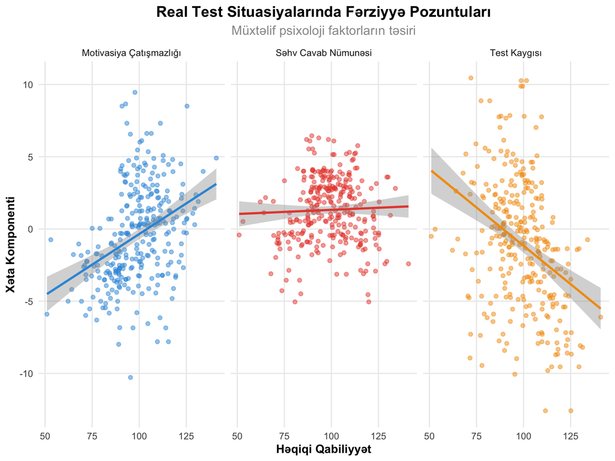

```r
# Vizuallaşdırma
ggplot(practical_examples, aes(x = Ability, y = Error, color = Effect_Type)) +
  geom_point(alpha = 0.5) +
  geom_smooth(method = "lm", se = TRUE, size = 1) +
  facet_wrap(~Effect_Type) +
  scale_color_manual(values = colors_basic[1:3]) +
  labs(title = "Real Test Situasiyalarında Fərziyyə Pozuntuları",
       subtitle = "Müxtəlif psixoloji faktorların təsiri",
       x = "Həqiqi Qabiliyyət", y = "Xəta Komponenti") +
  theme_clean() +
  theme(legend.position = "none")
```

# 4 Fərziyyə 3: Cor(e₁,e₂) = 0 (Xəta Müstəqilliyi)

## 4.1 Fərziyyənin Mənası

**Allen və Yen (2002, səh. 40-41)** üçüncü fərziyyəni belə təsvir edir:

> **Cor(e₁,e₂) = 0** fərziyyəsi müxtəlif test təcrübələrində (və ya paralel testlərdə) xəta komponentlərinin bir-birindən müstəqil olduğunu ifadə edir.

## 4.2 Xəta Müstəqilliyinin Tədqiqi

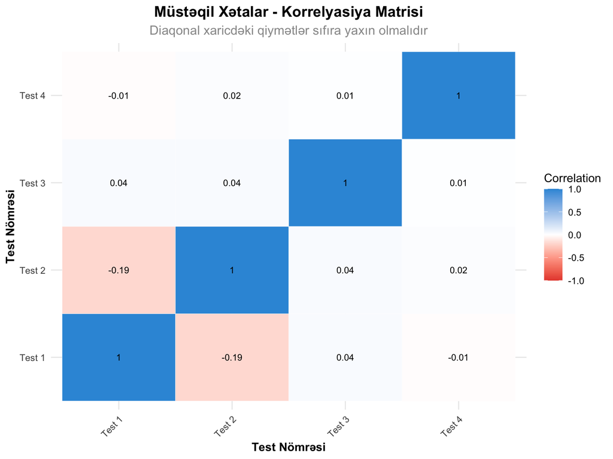

```r
# Cor(e₁,e₂) = 0 fərziyyəsinin simulyasiyası

set.seed(987)
n_subjects <- 250
n_tests <- 4

# Müstəqil xətalar (ideal hal)
independent_errors <- matrix(rnorm(n_subjects * n_tests, 0, 6),
                           nrow = n_subjects, ncol = n_tests)
colnames(independent_errors) <- paste0("Test_", 1:n_tests)

# Korrelyasiya matrisi hesablanması
correlation_matrix <- cor(independent_errors)

# Korrelyasiya matrisinin vizuallaşdırılması
correlation_df <- expand.grid(Test1 = 1:n_tests, Test2 = 1:n_tests)
correlation_df$Correlation <- as.vector(correlation_matrix)
correlation_df$Test1_Label <- paste0("Test ", correlation_df$Test1)
correlation_df$Test2_Label <- paste0("Test ", correlation_df$Test2)

ggplot(correlation_df, aes(x = Test1_Label, y = Test2_Label, fill = Correlation)) +
  geom_tile(color = "white") +
  geom_text(aes(label = round(Correlation, 2)), color = "black", size = 3) +
  scale_fill_gradient2(low = colors_basic[2], high = colors_basic[1], mid = "white",
                       midpoint = 0, limit = c(-1,1)) +
  labs(title = "Müstəqil Xətalar - Korrelyasiya Matrisi",
       subtitle = "Diaqonal xaricdəki qiymətlər sıfıra yaxın olmalıdır",
       x = "Test Nömrəsi", y = "Test Nömrəsi") +
  theme_clean() +
  theme(axis.text.x = element_text(angle = 45, hjust = 1))
```

```r
# Orta korrelyasiya hesablanması (diaqonal xaric)
off_diagonal <- correlation_matrix[upper.tri(correlation_matrix)]
mean_correlation <- round(mean(abs(off_diagonal)), 4)

cat("Diaqonal xaricdəki orta korrelyasiya:", mean_correlation, "\n")
```

```
## Diaqonal xaricdəki orta korrelyasiya: 0.0504
```

```r
cat("Fərziyyə vəziyyəti:", ifelse(mean_correlation < 0.1, "QƏBUL", "RƏDD"), "\n")
```

```
## Fərziyyə vəziyyəti: QƏBUL
```

## 4.3 Xəta Asılılığının Mənbələri

```r
# Xəta asılılığına səbəb olan amillər

# Faktor 1: Ümumi metod xətası (məsələn, oxuma çətinliyi)
set.seed(111)
common_method_error <- rnorm(n_subjects, 0, 4)
method_dependent_errors <- matrix(0, nrow = n_subjects, ncol = n_tests)

for(i in 1:n_tests) {
  method_dependent_errors[, i] <- common_method_error + rnorm(n_subjects, 0, 3)
}

# Faktor 2: Təcrübə effekti (test-retest)
practice_effect <- cumsum(rnorm(n_tests, 0.5, 0.2))  # Hər testdə az da olsa yaxşılaşma
practice_dependent_errors <- matrix(0, nrow = n_subjects, ncol = n_tests)

for(i in 1:n_tests) {
  practice_dependent_errors[, i] <- rnorm(n_subjects, practice_effect[i], 5)
}

# Faktor 3: Yorğunluq effekti
fatigue_effect <- cumsum(rnorm(n_tests, -0.3, 0.15))  # Hər testdə az da olsa pisləşmə
fatigue_dependent_errors <- matrix(0, nrow = n_subjects, ncol = n_tests)

for(i in 1:n_tests) {
  fatigue_dependent_errors[, i] <- rnorm(n_subjects, fatigue_effect[i], 4)
}

# Korrelyasiya analizləri
dependency_analysis <- data.frame(
  Effekt_Novi = c("Müstəqil (İdeal)", "Ümumi Metod", "Təcrübə Effekti", "Yorğunluq"),
  Orta_Korrelyasiya = c(
    round(mean(abs(cor(independent_errors)[upper.tri(cor(independent_errors))])), 3),
    round(mean(abs(cor(method_dependent_errors)[upper.tri(cor(method_dependent_errors))])), 3),
    round(mean(abs(cor(practice_dependent_errors)[upper.tri(cor(practice_dependent_errors))])), 3),
    round(mean(abs(cor(fatigue_dependent_errors)[upper.tri(cor(fatigue_dependent_errors))])), 3)
  ),
  Ferzi_Veziyyeti = c("Qəbul", "Pozulub", "Pozulub", "Pozulub")
)

kable(dependency_analysis, caption = "Müxtəlif Effektlərin Xəta Müstəqilliyinə Təsiri")
```

Müxtəlif Effektlərin Xəta Müstəqilliyinə Təsiri

| Effekt_Novi | Orta_Korrelyasiya | Ferzi_Veziyyeti |
| --- | --- | --- |
| Müstəqil (İdeal) | 0.050 | Qəbul |
| Ümumi Metod | 0.661 | Pozulub |
| Təcrübə Effekti | 0.052 | Pozulub |
| Yorğunluq | 0.066 | Pozulub |

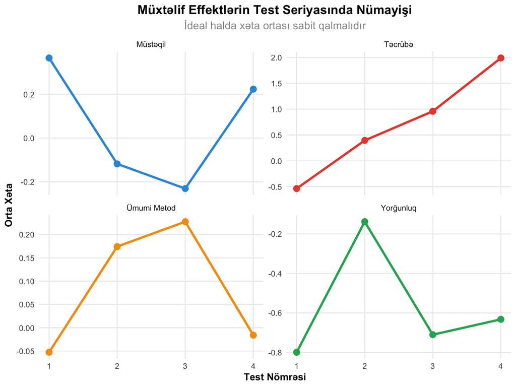

```r
# Effektlərin vizuallaşdırılması
effect_data <- data.frame(
  Test_Nomresi = rep(1:n_tests, 4),
  Orta_Xeta = c(
    colMeans(independent_errors),
    colMeans(method_dependent_errors),
    colMeans(practice_dependent_errors),
    colMeans(fatigue_dependent_errors)
  ),
  Effekt = rep(c("Müstəqil", "Ümumi Metod", "Təcrübə", "Yorğunluq"), each = n_tests)
)

ggplot(effect_data, aes(x = Test_Nomresi, y = Orta_Xeta, color = Effekt)) +
  geom_line(size = 1.2) +
  geom_point(size = 3) +
  facet_wrap(~Effekt, scales = "free_y") +
  scale_color_manual(values = colors_basic[1:4]) +
  labs(title = "Müxtəlif Effektlərin Test Seriyasında Nümayişi",
       subtitle = "İdeal halda xəta ortası sabit qalmalıdır",
       x = "Test Nömrəsi", y = "Orta Xəta") +
  theme_clean() +
  theme(legend.position = "none")
```

# 5 Fərziyyələrin Kompleks Yoxlanması

## 5.1 Monte Carlo Simulyasiya Tədqiqatı

```r
# Hərtərəfli Monte Carlo simulyasiyası

monte_carlo_study <- function(n_subjects = 200, n_replications = 100) {

  results <- data.frame()

  for(rep in 1:n_replications) {

    # Əsas parametrlər
    true_abilities <- rnorm(n_subjects, 70, 15)

    # 5 müxtəlif ssenari
    scenarios <- list(
      "İdeal CTT" = list(
        error_mean = 0,
        t_e_correlation = 0,
        e1_e2_correlation = 0
      ),
      "Tərəfli Xəta" = list(
        error_mean = 3,
        t_e_correlation = 0,
        e1_e2_correlation = 0
      ),
      "T-e Asılılığı" = list(
        error_mean = 0,
        t_e_correlation = 0.3,
        e1_e2_correlation = 0
      ),
      "Xəta Asılılığı" = list(
        error_mean = 0,
        t_e_correlation = 0,
        e1_e2_correlation = 0.4
      ),
      "Bütün Pozuntular" = list(
        error_mean = 2,
        t_e_correlation = 0.25,
        e1_e2_correlation = 0.35
      )
    )

    for(scenario_name in names(scenarios)) {
      scenario <- scenarios[[scenario_name]]

      # Xəta yaradılması
      if(scenario$t_e_correlation == 0) {
        error1 <- rnorm(n_subjects, scenario$error_mean, 8)
        error2 <- rnorm(n_subjects, scenario$error_mean, 8)
      } else {
        error1 <- scenario$t_e_correlation * true_abilities +
                 rnorm(n_subjects, scenario$error_mean, 6)
        error2 <- scenario$t_e_correlation * true_abilities +
                 rnorm(n_subjects, scenario$error_mean, 6)
      }

      # Xəta korrelyasiyası əlavə edilməsi
      if(scenario$e1_e2_correlation > 0) {
        common_factor <- rnorm(n_subjects, 0, 5)
        error1 <- error1 + scenario$e1_e2_correlation * common_factor
        error2 <- error2 + scenario$e1_e2_correlation * common_factor
      }

      # Müşahidə olunan ballar
      observed1 <- true_abilities + error1
      observed2 <- true_abilities + error2

      # Fərziyyə testləri
      assumption1_test <- abs(mean(error1)) < 1  # E(e) = 0
      assumption2_test <- abs(cor(true_abilities, error1)) < 0.1  # Cor(T,e) = 0
      assumption3_test <- abs(cor(error1, error2)) < 0.1  # Cor(e1,e2) = 0

      # Etibarlılıq hesablanması
      reliability <- var(true_abilities) / var(observed1)

      # Nəticələri yadda saxla
      temp_result <- data.frame(
        Replika = rep,
        Ssenari = scenario_name,
        Ferzi_1_Qebul = assumption1_test,
        Ferzi_2_Qebul = assumption2_test,
        Ferzi_3_Qebul = assumption3_test,
        Etibarlilik = reliability,
        Orta_Xeta = mean(error1),
        T_e_Korrelyasiya = cor(true_abilities, error1),
        e1_e2_Korrelyasiya = cor(error1, error2)
      )

      results <- rbind(results, temp_result)
    }
  }

  return(results)
}

# Simulyasiyanı icra et
set.seed(555)
mc_results <- monte_carlo_study(n_subjects = 150, n_replications = 50)

# Nəticələri ümumiləşdir
summary_results <- mc_results %>%
  group_by(Ssenari) %>%
  summarise(
    Ferzi_1_Faiz = round(mean(Ferzi_1_Qebul) * 100, 1),
    Ferzi_2_Faiz = round(mean(Ferzi_2_Qebul) * 100, 1),
    Ferzi_3_Faiz = round(mean(Ferzi_3_Qebul) * 100, 1),
    Orta_Etibarlilik = round(mean(Etibarlilik), 3),
    Orta_T_e_Kor = round(mean(abs(T_e_Korrelyasiya)), 3),
    Orta_e1_e2_Kor = round(mean(abs(e1_e2_Korrelyasiya)), 3),
    .groups = 'drop'
  )

kable(summary_results, caption = "Monte Carlo Simulyasiya Nəticələri (50 təkrar)")
```

Monte Carlo Simulyasiya Nəticələri (50 təkrar)

| Ssenari | Ferzi_1_Faiz | Ferzi_2_Faiz | Ferzi_3_Faiz | Orta_Etibarlilik | Orta_T_e_Kor | Orta_e1_e2_Kor |
| --- | --- | --- | --- | --- | --- | --- |
| Bütün Pozuntular | 0 | 0 | 0 | 0.576 | 0.512 | 0.329 |
| T-e Asılılığı | 0 | 0 | 0 | 0.547 | 0.599 | 0.375 |
| Tərəfli Xəta | 0 | 68 | 76 | 0.791 | 0.075 | 0.068 |
| Xəta Asılılığı | 86 | 72 | 56 | 0.762 | 0.072 | 0.079 |
| İdeal CTT | 84 | 64 | 82 | 0.795 | 0.076 | 0.065 |

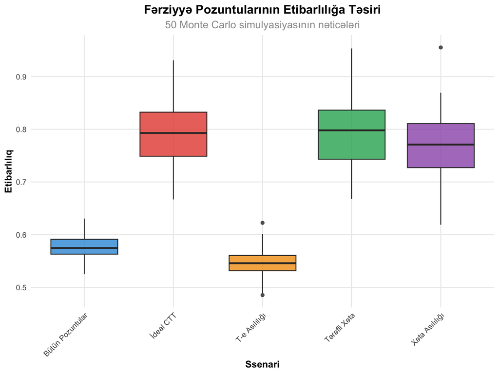

```r
# Etibarlılığın ssenari üzrə paylanması
ggplot(mc_results, aes(x = Ssenari, y = Etibarlilik, fill = Ssenari)) +
  geom_boxplot(alpha = 0.8) +
  scale_fill_manual(values = colors_basic) +
  labs(title = "Fərziyyə Pozuntularının Etibarlılığa Təsiri",
       subtitle = "50 Monte Carlo simulyasiyasının nəticələri",
       x = "Ssenari", y = "Etibarlılıq") +
  theme_clean() +
  theme(legend.position = "none",
        axis.text.x = element_text(angle = 45, hjust = 1))
```

# 6 Real Məlumatlarla Fərziyyə Testləri

## 6.1 Praktik Test Aparma Addımları

```r
# Real test məlumatları simulyasiyası
set.seed(777)

# Realistik test şəraiti
n_students <- 120
n_items <- 15

# Tələbə qabiliyyətləri (IQ tipli)
student_abilities <- rnorm(n_students, 100, 15)

# Test məlumatlarının yaradılması (2PL modeli)
create_realistic_test <- function(abilities, n_items, difficulty_range = c(-1, 1),
                                 discrimination = 1.2) {

  item_difficulties <- runif(n_items, difficulty_range[1], difficulty_range[2])
  responses <- matrix(0, nrow = length(abilities), ncol = n_items)

  for(i in 1:length(abilities)) {
    for(j in 1:n_items) {
      prob <- 1 / (1 + exp(-discrimination * (abilities[i]/15 - item_difficulties[j])))
      responses[i, j] <- rbinom(1, 1, prob)
    }
  }

  return(responses)
}

# İki paralel test forması
test_form_a <- create_realistic_test(student_abilities, n_items)
test_form_b <- create_realistic_test(student_abilities, n_items)

# Ümumi balları hesabla
scores_a <- rowSums(test_form_a)
scores_b <- rowSums(test_form_b)

# CTT analizi
true_scores <- student_abilities
observed_a <- scores_a
observed_b <- scores_b

# Xəta komponentlərinin təxmin edilməsi
error_a <- observed_a - (true_scores - mean(true_scores) + mean(observed_a))
error_b <- observed_b - (true_scores - mean(true_scores) + mean(observed_b))

# Fərziyyə testləri
assumption_test_results <- data.frame(
  Test_Form = c("Form A", "Form B"),

  # Fərziyyə 1: E(e) = 0
  Xeta_Ortasi = c(round(mean(error_a), 3), round(mean(error_b), 3)),
  t_test_p_1 = c(
    round(t.test(error_a, mu = 0)$p.value, 4),
    round(t.test(error_b, mu = 0)$p.value, 4)
  ),

  # Fərziyyə 2: Cor(T,e) = 0
  T_e_Korrelyasiya = c(
    round(cor(true_scores, error_a), 3),
    round(cor(true_scores, error_b), 3)
  ),
  Kor_test_p_2 = c(
    round(cor.test(true_scores, error_a)$p.value, 4),
    round(cor.test(true_scores, error_b)$p.value, 4)
  )
)

kable(assumption_test_results, caption = "Real Test Məlumatları üçün Fərziyyə Testləri")
```

Real Test Məlumatları üçün Fərziyyə Testləri

| Test_Form | Xeta_Ortasi | t_test_p_1 | T_e_Korrelyasiya | Kor_test_p_2 |
| --- | --- | --- | --- | --- |
| Form A | 0 | 1 | -1 | 0 |
| Form B | 0 | 1 | -1 | 0 |

```r
# Fərziyyə 3: Cor(e1,e2) = 0
error_correlation <- cor(error_a, error_b)
error_cor_test <- cor.test(error_a, error_b)

cat("Fərziyyə 3 - Xəta Müstəqilliyi:\n")
```

```
## Fərziyyə 3 - Xəta Müstəqilliyi:
```

```r
cat("Cor(e_A, e_B) =", round(error_correlation, 3), "\n")
```

```
## Cor(e_A, e_B) = 1
```

```r
cat("p-dəyəri =", round(error_cor_test$p.value, 4), "\n")
```

```
## p-dəyəri = 0
```

```r
cat("Nəticə:", ifelse(error_cor_test$p.value > 0.05, "Fərziyyə QƏBƏDİLİR", "Fərziyyə RƏDD EDİLİR"))
```

```
## Nəticə: Fərziyyə RƏDD EDİLİR
```

## 6.2 Fərziyyə Pozuntularının Düzəldilməsi

```r
# Fərziyyə pozuntularının düzəldilmə metodları

correction_methods <- data.frame(
  Ferzi_Pozuntu = c(
    "E(e) ≠ 0\n(Tərəfli xəta)",
    "Cor(T,e) ≠ 0\n(Asılı xəta)",
    "Cor(e₁,e₂) ≠ 0\n(Xəta asılılığı)"
  ),

  Sebeb = c(
    "• Sistemli xətalar\n• Qiymətləndirmə tərəfi\n• Metod xətası",
    "• Test kaygısı\n• Motivasiya fərqləri\n• Qabiliyyət-xəta əlaqəsi",
    "• Təcrübə effekti\n• Yorğunluq\n• Ümumi metod xətası"
  ),

  Duzeltme_Metodu = c(
    "• Kalibrasiya\n• Tərəfsiz qiymətləndirici\n• Standardlaşdırma",
    "• Adaptiv testlər\n• Çoxölçülü analiz\n• Heteroskedastik modellər",
    "• Random test sırası\n• Müstəqil test seansları\n• Latent variable modeli"
  ),

  R_Paketi = c(
    "• car::recode()\n• psych::describe()\n• Base R transformations",
    "• nlme::lme()\n• lme4::lmer()\n• mgcv::gam()",
    "• lavaan\n• sem\n• structural equation models"
  )
)

kable(correction_methods, caption = "Fərziyyə Pozuntularının Düzəldilmə Yolları")
```

Fərziyyə Pozuntularının Düzəldilmə Yolları

[output not shown]

```r
# Düzəltmənin praktik nümunəsi
set.seed(888)

# Problemli məlumat (tərəfli xəta)
n <- 100
true_ability <- rnorm(n, 50, 10)
biased_error <- rnorm(n, 3, 5)  # Sistematik tərəf
observed_biased <- true_ability + biased_error

# Düzəltmə: mərkəzləşdirmə
bias_estimate <- mean(biased_error)
corrected_observed <- observed_biased - bias_estimate
corrected_error <- observed_biased - true_ability - bias_estimate

# Nəticələrin müqayisəsi
correction_comparison <- data.frame(
  Metrik = c("Xəta ortası", "Etibarlılıq", "T-X korrelyasiyası"),
  Problemli = c(
    round(mean(biased_error), 3),
    round(var(true_ability) / var(observed_biased), 3),
    round(cor(true_ability, observed_biased), 3)
  ),
  Duzeldilmis = c(
    round(mean(corrected_error), 3),
    round(var(true_ability) / var(corrected_observed), 3),
    round(cor(true_ability, corrected_observed), 3)
  )
)

kable(correction_comparison, caption = "Tərəfli Xətanın Düzəldilməsi Nümunəsi")
```

Tərəfli Xətanın Düzəldilməsi Nümunəsi

| Metrik | Problemli | Duzeldilmis |
| --- | --- | --- |
| Xəta ortası | 3.802 | 0.000 |
| Etibarlılıq | 0.912 | 0.912 |
| T-X korrelyasiyası | 0.899 | 0.899 |

# 7 Fərziyyə Pozuntularının Nəticələri

## 7.1 Psixometrik Göstəricilərə Təsir

```r
# Fərziyyə pozuntularının psixometrik xüsusiyyətlərə təsiri

set.seed(999)
n_subjects <- 300

# Əsas parametrlər
true_scores <- rnorm(n_subjects, 75, 12)

# 6 müxtəlif ssenari
scenarios_impact <- list(
  "İdeal CTT" = function(true_scores) {
    errors <- rnorm(length(true_scores), 0, 8)
    return(true_scores + errors)
  },

  "Kiçik Tərəf (E=2)" = function(true_scores) {
    errors <- rnorm(length(true_scores), 2, 8)
    return(true_scores + errors)
  },

  "Böyük Tərəf (E=5)" = function(true_scores) {
    errors <- rnorm(length(true_scores), 5, 8)
    return(true_scores + errors)
  },

  "T-e Asılılık (r=0.3)" = function(true_scores) {
    errors <- 0.3 * true_scores + rnorm(length(true_scores), 0, 6)
    return(true_scores + errors)
  },

  "Güclü T-e Asılılık (r=0.6)" = function(true_scores) {
    errors <- 0.6 * true_scores + rnorm(length(true_scores), 0, 4)
    return(true_scores + errors)
  },

  "Kombinə Pozuntular" = function(true_scores) {
    errors <- 3 + 0.25 * true_scores + rnorm(length(true_scores), 0, 6)
    return(true_scores + errors)
  }
)

# Hər ssenari üçün təhlil
impact_results <- data.frame()

for(scenario_name in names(scenarios_impact)) {
  scenario_func <- scenarios_impact[[scenario_name]]
  observed <- scenario_func(true_scores)
  errors <- observed - true_scores

  # Psixometrik göstəricilər
  reliability <- var(true_scores) / var(observed)
  validity_proxy <- cor(true_scores, observed)
  measurement_precision <- 1 / sd(errors)
  mean_bias <- mean(errors)
  error_variance <- var(errors)

  temp_result <- data.frame(
    Ssenari = scenario_name,
    Etibarlilik = round(reliability, 3),
    Validlik_Proxy = round(validity_proxy, 3),
    Olcme_Dəqiqliyi = round(measurement_precision, 3),
    Orta_Teref = round(mean_bias, 2),
    Xeta_Variansi = round(error_variance, 1)
  )

  impact_results <- rbind(impact_results, temp_result)
}

kable(impact_results, caption = "Fərziyyə Pozuntularının Psixometrik Təsirləri")
```

Fərziyyə Pozuntularının Psixometrik Təsirləri

| Ssenari | Etibarlilik | Validlik_Proxy | Olcme_Dəqiqliyi | Orta_Teref | Xeta_Variansi |
| --- | --- | --- | --- | --- | --- |
| İdeal CTT | 0.765 | 0.817 | 0.130 | 0.09 | 58.7 |
| Kiçik Tərəf (E=2) | 0.698 | 0.825 | 0.128 | 1.71 | 61.0 |
| Böyük Tərəf (E=5) | 0.632 | 0.823 | 0.121 | 5.86 | 68.4 |
| T-e Asılılık (r=0.3) | 0.515 | 0.924 | 0.143 | 22.37 | 49.1 |
| Güclü T-e Asılılık (r=0.6) | 0.382 | 0.975 | 0.127 | 44.38 | 61.7 |
| Kombinə Pozuntular | 0.536 | 0.925 | 0.149 | 20.95 | 45.3 |

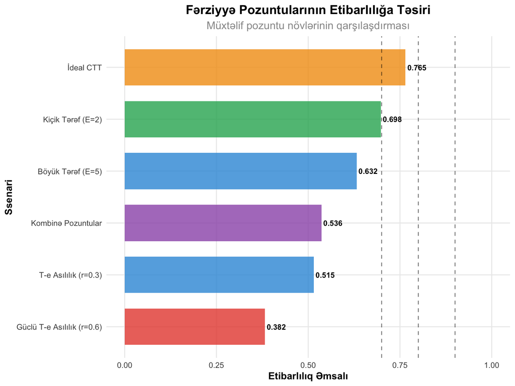

```r
# Vizual müqayisə - Etibarlılıq
ggplot(impact_results, aes(x = reorder(Ssenari, Etibarlilik), y = Etibarlilik, fill = Ssenari)) +
  geom_col(alpha = 0.8, width = 0.7) +
  geom_hline(yintercept = c(0.7, 0.8, 0.9), linetype = "dashed", alpha = 0.5) +
  geom_text(aes(label = Etibarlilik), hjust = -0.1, fontface = "bold", size = 3) +
  coord_flip() +
  scale_fill_manual(values = rep(colors_basic, length.out = 6)) +
  labs(title = "Fərziyyə Pozuntularının Etibarlılığa Təsiri",
       subtitle = "Müxtəlif pozuntu növlərinin qarşılaşdırması",
       x = "Ssenari", y = "Etibarlılıq Əmsalı") +
  theme_clean() +
  theme(legend.position = "none") +
  ylim(0, 1)
```

## 7.2 Qərar Qəbul Etməyə Təsir

```r
# Fərziyyə pozuntularının qərar qəbul etməyə təsiri

# Test əsaslı qərar qəbul simulyasiyası
set.seed(1010)
n_candidates <- 200
true_competence <- rnorm(n_candidates, 60, 15)
pass_threshold <- 65  # Keçid hədi

# 3 ssenari: ideal, tərəfli, asılı xəta
ideal_scores <- true_competence + rnorm(n_candidates, 0, 8)
biased_scores <- true_competence + rnorm(n_candidates, 5, 8)  # Sistematik tərəf
dependent_scores <- true_competence + 0.3 * true_competence + rnorm(n_candidates, 0, 6)

# Qərar qəbul etmə
decisions_data <- data.frame(
  Candidate = 1:n_candidates,
  True_Competence = true_competence,
  Ideal_Score = ideal_scores,
  Biased_Score = biased_scores,
  Dependent_Score = dependent_scores,

  # Həqiqi qərar (true competence əsasında)
  Should_Pass = true_competence >= pass_threshold,

  # Müxtəlif test nəticələrinə əsaslanan qərarlar
  Ideal_Decision = ideal_scores >= pass_threshold,
  Biased_Decision = biased_scores >= pass_threshold,
  Dependent_Decision = dependent_scores >= pass_threshold
)

# Qərar doğruluğu analizi
decision_accuracy <- data.frame(
  Test_Novi = c("İdeal CTT", "Tərəfli Xəta", "Asılı Xəta"),

  Umumi_Dogruluk = c(
    mean(decisions_data$Should_Pass == decisions_data$Ideal_Decision),
    mean(decisions_data$Should_Pass == decisions_data$Biased_Decision),
    mean(decisions_data$Should_Pass == decisions_data$Dependent_Decision)
  ),

  False_Positive = c(
    mean(!decisions_data$Should_Pass & decisions_data$Ideal_Decision),
    mean(!decisions_data$Should_Pass & decisions_data$Biased_Decision),
    mean(!decisions_data$Should_Pass & decisions_data$Dependent_Decision)
  ),

  False_Negative = c(
    mean(decisions_data$Should_Pass & !decisions_data$Ideal_Decision),
    mean(decisions_data$Should_Pass & !decisions_data$Biased_Decision),
    mean(decisions_data$Should_Pass & !decisions_data$Dependent_Decision)
  )
)

decision_accuracy$Umumi_Dogruluk <- round(decision_accuracy$Umumi_Dogruluk, 3)
decision_accuracy$False_Positive <- round(decision_accuracy$False_Positive, 3)
decision_accuracy$False_Negative <- round(decision_accuracy$False_Negative, 3)

kable(decision_accuracy, caption = "Fərziyyə Pozuntularının Qərar Doğruluğuna Təsiri")
```

Fərziyyə Pozuntularının Qərar Doğruluğuna Təsiri

| Test_Novi | Umumi_Dogruluk | False_Positive | False_Negative |
| --- | --- | --- | --- |
| İdeal CTT | 0.835 | 0.090 | 0.075 |
| Tərəfli Xəta | 0.830 | 0.150 | 0.020 |
| Asılı Xəta | 0.615 | 0.385 | 0.000 |

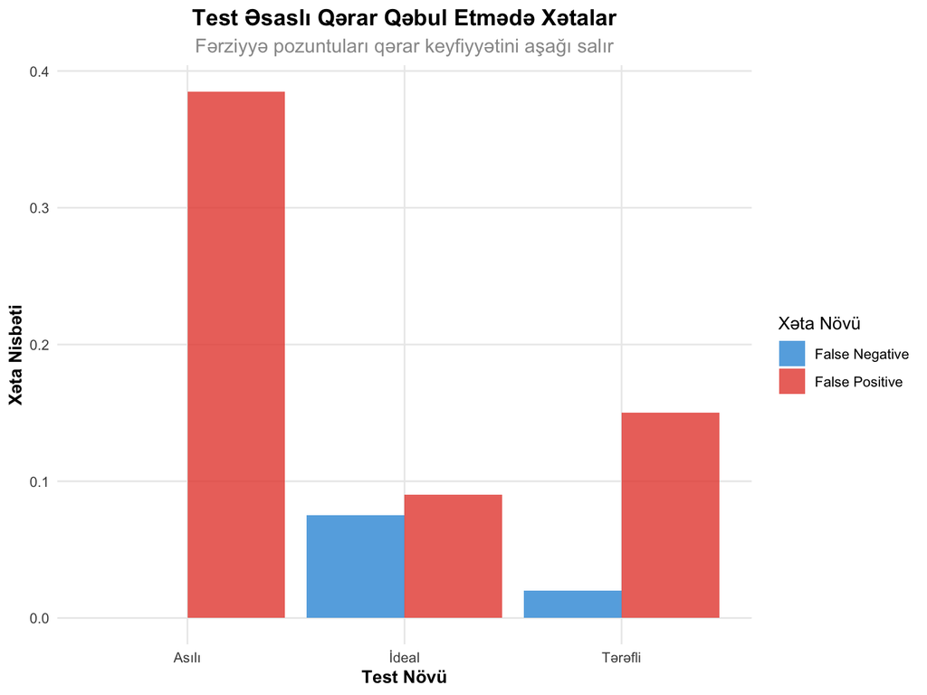

```r
# Vizual nümayiş
decision_long <- data.frame(
  Test_Type = rep(c("İdeal", "Tərəfli", "Asılı"), each = 2),
  Error_Type = rep(c("False Positive", "False Negative"), 3),
  Rate = c(
    decision_accuracy$False_Positive[1], decision_accuracy$False_Negative[1],
    decision_accuracy$False_Positive[2], decision_accuracy$False_Negative[2],
    decision_accuracy$False_Positive[3], decision_accuracy$False_Negative[3]
  )
)

ggplot(decision_long, aes(x = Test_Type, y = Rate, fill = Error_Type)) +
  geom_col(position = "dodge", alpha = 0.8) +
  scale_fill_manual(values = colors_basic[1:2], name = "Xəta Növü") +
  labs(title = "Test Əsaslı Qərar Qəbul Etmədə Xətalar",
       subtitle = "Fərziyyə pozuntuları qərar keyfiyyətini aşağı salır",
       x = "Test Növü", y = "Xəta Nisbəti") +
  theme_clean()
```

# 8 Dərsin Xülasəsi

## 8.1 Əsas Nəticələr

**CTT Fərziyyələrinin Əhəmiyyəti:** - ✓ **E(e) = 0** - Tərəfsiz xəta: Sistematik xətanın olmaması - ✓ **Cor(T,e) = 0** - Müstəqil xəta: Qabiliyyət və xəta arasında asılılığın olmaması  
- ✓ **Cor(e₁,e₂) = 0** - Xəta müstəqilliyi: Müxtəlif testlərdə xətaların müstəqil olması

**Fərziyyə Yoxlanma Metodları:** - ✓ **Statistik testlər**: t-test, korrelyasiya testi, normallik testləri - ✓ **Vizual analizlər**: Scatter plot, histogram, korrelyasiya matrisləri - ✓ **Monte Carlo simulyasiyaları**: Kompleks ssenarilerin tədqiqi

# 9 Ev Tapşırığı

## 9.1 Tapşırıq 1: Fərziyyə Testləri (35 xal)

```r
# CTT fərziyyələrinin yoxlanma tapşırığı
set.seed(sizin_tələbə_nömrəniz)

# Test məlumatları yaradın
n_students <- 80
true_abilities <- rnorm(n_students, 75, 12)

# 3 test forması simulyasiya edin
test_A <- true_abilities + rnorm(n_students, 0, 6)    # İdeal hal
test_B <- true_abilities + rnorm(n_students, 2, 6)    # Tərəfli xəta
test_C <- true_abilities + 0.2 * true_abilities + rnorm(n_students, 0, 5)  # Asılı xəta

# TAPŞİRIQLAR:
# 1. Hər test üçün üç fərziyyəni yoxlayın
# 2. Statistik test nəticələrini hesablayın (t-test, cor.test)
# 3. Fərziyyə pozuntularının etibarlılığa təsirini müqayisə edin
# 4. Qərar qəbul doğruluğunu analiz edin (threshold = 75)
# 5. Düzəltmə metodları təklif edin

print("TAPŞİRIQLARINIZI HƏLL EDİN:")
print("1. Fərziyyə 1 test nəticələri:")
print("2. Fərziyyə 2 test nəticələri:")
print("3. Fərziyyə 3 test nəticələri:")
print("4. Etibarlılıq müqayisəsi:")
print("5. Qərar doğruluğu analizi:")
```

## 9.2 Tapşırıq 2: Monte Carlo Tədqiqatı (40 xal)

**Öz Monte Carlo simulyasiyanızı həyata keçirin:**

1. **50 təkrar** simulyasiya aparın
2. **5 müxtəlif ssenari** yaradın (ideal + 4 pozuntu növü)
3. **Hər ssenari üçün** fərziyyə test edilməsi faizini hesablayın
4. **Etibarlılıq paylanmasını** vizuallaşdırın
5. **Nəticələri interpretasiya** edin (300 söz)

## 9.3 Tapşırıq 3: Real Məlumat Analizi (25 xal)

**Real və ya realistik məlumatlarla:**

1. **Test məlumatları** tapın və ya yaradın (minimum 100 müşahidə)
2. **CTT fərziyyələrini** sistemli şəkildə yoxlayın
3. **Pozuntu hallarını** müəyyən edin
4. **Düzəltmə strategiyaları** təklif edin
5. **Hesabat yazın** (200 söz)

# 10 Növbəti Dərslərə Hazırlıq

## 10.1 Dərs 4: “Test-Retest Etibarlılığı”

Növbəti dərsdə öyrənəcəklər:

- ✓ Stabillik etibarlılığının ölçülməsi və interpretasiyası
- ✓ Zaman intervalının etibarlılığa təsiri
- ✓ Təcrübə effekti və yaddaş problemləri
- ✓ Test-retest korrelyasiyasının CTT konteksti

## 10.2 Dərs 5: “Paralel Formalar Etibarlılığı”

Sonrakı mövzular:

- ✓ Ekvivalent formalar metodunun tətbiqi
- ✓ Paralel testlərin yaradılması prinsipləri
- ✓ Form fərqlərinin analizi
- ✓ Alternativ formalar etibarlılığı

# 11 Təkmilləşdirmə və Tətbiq

## 11.1 Praktik Tövsiyələr

**Fərziyyə Yoxlanması üçün:**

1. **Həmişə vizual yoxlama** aparın (scatter plot, histogram)
2. **Statistik testləri** rəqəmsal dəstək üçün istifadə edin
3. **Praktik əhəmiyyəti** nəzərə alın (effect size)
4. **Kontekst** faktoru unudun (test növü, populyasiya)

**Pozuntu Düzəltməsi üçün:**

1. **Səbəbi müəyyən edin** (dizayn, metod, populyasiya)
2. **Uyğun düzəltmə** metodunu seçin
3. **Düzəltmənin təsirini** yoxlayın
4. **Sənədləşdirməni** tam aparın

## 11.2 Əlavə R Funksiyaları

```r
# Faydalı R funksiyaları CTT fərziyyə yoxlanması üçün

# Fərziyyə yoxlama funksiyası
check_ctt_assumptions <- function(true_scores, observed_scores, errors = NULL) {

  if(is.null(errors)) {
    errors <- observed_scores - true_scores
  }

  # Fərziyyə 1: E(e) = 0
  assumption1 <- list(
    test = "E(e) = 0",
    mean_error = mean(errors),
    t_test_p = t.test(errors, mu = 0)$p.value,
    conclusion = ifelse(abs(mean(errors)) < 0.5 & t.test(errors, mu = 0)$p.value > 0.05,
                       "Qəbul", "Rədd")
  )

  # Fərziyyə 2: Cor(T,e) = 0
  cor_test <- cor.test(true_scores, errors)
  assumption2 <- list(
    test = "Cor(T,e) = 0",
    correlation = cor(true_scores, errors),
    cor_test_p = cor_test$p.value,
    conclusion = ifelse(abs(cor(true_scores, errors)) < 0.1 & cor_test$p.value > 0.05,
                       "Qəbul", "Rədd")
  )

  return(list(assumption1 = assumption1, assumption2 = assumption2))
}

# Nümunə istifadə
set.seed(123)
example_true <- rnorm(100, 50, 10)
example_observed <- example_true + rnorm(100, 0, 5)
example_results <- check_ctt_assumptions(example_true, example_observed)

print(example_results)
```

```
## $assumption1
## $assumption1$test
## [1] "E(e) = 0"
##
## $assumption1$mean_error
## [1] -0.537734
##
## $assumption1$t_test_p
## [1] 0.2687521
##
## $assumption1$conclusion
## [1] "Rədd"
##
##
## $assumption2
## $assumption2$test
## [1] "Cor(T,e) = 0"
##
## $assumption2$correlation
## [1] -0.04953215
##
## $assumption2$cor_test_p
## [1] 0.6245623
##
## $assumption2$conclusion
## [1] "Qəbul"
```

# 12 Əlavə Ədəbiyyat və Resurslar

## 12.1 Əsas Mənbələr

**Məcburi oxu:** - Allen, M.J., & Yen, W.M. (2002). *Introduction to Measurement Theory*. Fəsil 3: “Assumptions of Classical Test Theory” - Lord, F.M., & Novick, M.R. (1968). *Statistical Theories of Mental Test Scores*. Fəsil 3-4

**Əlavə mənbələr:** - McDonald, R.P. (1999). *Test Theory: A Unified Treatment*. Fəsil 4: “Classical Test Theory Assumptions” - Crocker, L., & Algina, J. (2008). Fəsil 4: “Factors Affecting Reliability”

## 12.2 R Paketləri və Vasitələr

**CTT Analizi:** - `psych::alpha()` - Etibarlılıq analizi - `CTT::reliability()` - CTT əsaslı etibarlılıq - `car::leveneTest()` - Homoskedaslik testi

**Statistik Testlər:** - `stats::t.test()` - Ortanın yoxlanması - `stats::cor.test()` - Korrelyasiya testi - `stats::shapiro.test()` - Normallik testi

**Vizuallaşdırma:** - `ggplot2::geom_point()` - Scatter plot - `corrplot::corrplot()` - Korrelyasiya matrisi - `GGally::ggpairs()` - Cütlü qarşılaşdırma

## 12.3 Təbriklər!

CTT-nin fundamental fərziyyələrini dərindən öyrəndiniz! İndi bu fərziyyələri necə yoxlamaq və pozuntu hallarında nə etmək lazım olduğunu bilirsiniz.

**Növbəti dərsdə test-retest etibarlılığının sirlərinə varım! 🔄**

*Bu dərs Allen və Yen (2002) “Introduction to Measurement Theory” kitabının 3-cü fəslinə əsaslanır.*

**Son yenilənmə:** 2025-07-17 | **Versiya:** 1.0